# Deposits, Vault Cash, and Loans and Bills Discounted by Prefecture(Domestically Licensed Banks)

アセット･マネジメント･コンサルティング株式会社 http://am-consulting.co.jp

2017-05-31 15:48:49

- アセット･マネジメント･コンサルティング株式会社 http://am-consulting.co.jp
- SaECaNet http://saecanet.com/
- Olive http://olive.saecanet.com/
- twitter https://twitter.com/AMC2_Japan
- 本ページへのリンクを共有:[Tweet](https://twitter.com/share)
- タイトル : 都道府県別預金・現金・貸出金(国内銀行)<2017年4月末>:全国計:751.8491(兆円)
- データ出所 : 日本銀行
- Source http://www.boj.or.jp/statistics/dl/depo/pref/index.htm/
- Source http://www.boj.or.jp/statistics/outline/exp/exyo.htm/
- 国内銀行銀行勘定は以下を除く(上記URLより引用)
  - 整理回収機構(1999年3月以前は整理回収銀行)
  - 紀伊預金管理銀行(2002年3月31日付けで解散)
  - 日本承継銀行(2004年3月8日付けで解散)
  - 第二日本承継銀行(2011年12月26日付で事業譲渡)
  - ゆうちょ銀行

#### 直近の状況

##### 都道府県別預金・現金・貸出金(国内銀行)<2017年4月末>

| ID | 都道府県別 | 預金(億円) | 譲渡性預金(億円) | 金融機関保有現金(億円) | 貸出金(億円) |
| --- | --- | --- | --- | --- | --- |
| 1 | 北海道 | 156393 | 2474 | 1732 | 98696 |
| 2 | 青森 | 41219 | 2062 | 496 | 25467 |
| 3 | 岩手 | 47523 | 1621 | 594 | 22602 |
| 4 | 宮城 | 103273 | 7763 | 906 | 63237 |
| 5 | 秋田 | 35659 | 1986 | 469 | 20353 |
| 6 | 山形 | 41361 | 1541 | 624 | 23994 |
| 7 | 福島 | 76576 | 5197 | 600 | 33739 |
| 8 | 東北計 | 345613 | 20172 | 3690 | 189395 |
| 9 | 茨城 | 113007 | 604 | 1139 | 59801 |
| 10 | 栃木 | 77487 | 2818 | 929 | 46593 |

[output cut: 46 more lines]

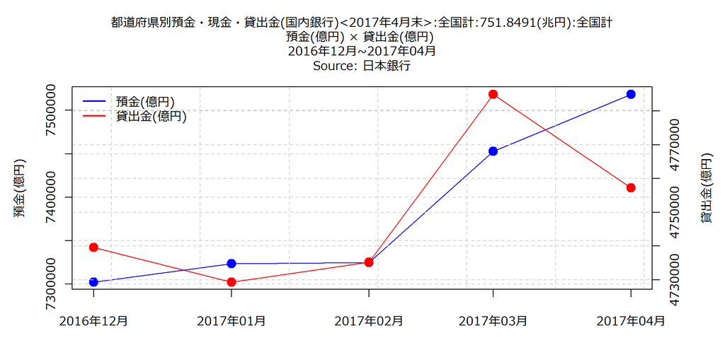

**都道府県別預金・現金・貸出金(国内銀行)<2017年4月末>**

| 都道府県別 | 預金(億円) | 譲渡性預金(億円) | 金融機関保有現金(億円) | 貸出金(億円) |
| --- | --- | --- | --- | --- |
| 東北計 | 345,613 | 20,172 | 3,690 | 189,395 |
| 関東計 | 3,830,298 | 254,046 | 51,242 | 2,646,001 |
| 北陸計 | 221,133 | 7,688 | 2,184 | 124,856 |
| 中部計 | 776,055 | 11,954 | 8,663 | 398,914 |
| 近畿計 | 1,158,124 | 13,710 | 9,835 | 610,699 |
| 中国計 | 315,189 | 10,836 | 3,526 | 197,553 |
| 四国計 | 193,516 | 5,839 | 2,124 | 115,890 |
| 九州・沖縄計 | 522,166 | 15,039 | 6,158 | 375,279 |
| 全国計 | 7,518,491 | 341,761 | 89,157 | 4,757,287 |

**都道府県別預金・現金・貸出金(国内銀行)<2017年3月末>**

| 都道府県別 | 預金(億円) | 譲渡性預金(億円) | 金融機関保有現金(億円) | 貸出金(億円) |
| --- | --- | --- | --- | --- |
| 東北計 | 346,357 | 18,373 | 3,977 | 191,055 |
| 関東計 | 3,785,049 | 255,383 | 41,894 | 2,659,171 |
| 北陸計 | 218,965 | 7,548 | 2,269 | 125,188 |
| 中部計 | 771,484 | 12,126 | 8,938 | 401,645 |
| 近畿計 | 1,153,674 | 13,825 | 10,678 | 617,249 |
| 中国計 | 312,471 | 10,013 | 3,131 | 197,181 |
| 四国計 | 191,897 | 5,846 | 1,924 | 116,624 |
| 九州・沖縄計 | 516,456 | 13,836 | 6,479 | 377,444 |
| 全国計 | 7,452,949 | 338,043 | 81,097 | 4,784,942 |

**都道府県別預金・現金・貸出金(国内銀行)<2017年2月末>**

| 都道府県別 | 預金(億円) | 譲渡性預金(億円) | 金融機関保有現金(億円) | 貸出金(億円) |
| --- | --- | --- | --- | --- |
| 東北計 | 337,599 | 20,312 | 3,487 | 187,833 |
| 関東計 | 3,710,474 | 246,123 | 39,406 | 2,632,880 |
| 北陸計 | 215,788 | 7,928 | 1,941 | 123,863 |
| 中部計 | 760,607 | 10,861 | 7,381 | 396,617 |
| 近畿計 | 1,137,608 | 11,950 | 10,515 | 609,934 |
| 中国計 | 309,373 | 12,690 | 2,907 | 196,281 |
| 四国計 | 190,568 | 6,814 | 1,827 | 114,692 |
| 九州・沖縄計 | 509,770 | 17,615 | 5,786 | 374,070 |
| 全国計 | 7,324,570 | 338,311 | 75,003 | 4,735,206 |

**都道府県別預金・現金・貸出金(国内銀行)<2017年1月末>**

| 都道府県別 | 預金(億円) | 譲渡性預金(億円) | 金融機関保有現金(億円) | 貸出金(億円) |
| --- | --- | --- | --- | --- |
| 東北計 | 337,570 | 20,825 | 3,610 | 187,384 |
| 関東計 | 3,721,609 | 252,326 | 55,340 | 2,631,189 |
| 北陸計 | 215,261 | 7,932 | 2,055 | 123,874 |
| 中部計 | 759,131 | 11,200 | 7,837 | 397,832 |
| 近畿計 | 1,132,992 | 13,343 | 10,210 | 607,762 |
| 中国計 | 308,148 | 13,567 | 3,060 | 195,627 |
| 四国計 | 190,092 | 7,102 | 1,888 | 114,607 |
| 九州・沖縄計 | 506,831 | 19,068 | 5,876 | 372,324 |
| 全国計 | 7,323,416 | 350,841 | 91,737 | 4,729,368 |

**都道府県別預金・現金・貸出金(国内銀行)<2016年12月末>**

| 都道府県別 | 預金(億円) | 譲渡性預金(億円) | 金融機関保有現金(億円) | 貸出金(億円) |
| --- | --- | --- | --- | --- |
| 東北計 | 341,723 | 21,876 | 4,269 | 188,252 |
| 関東計 | 3,681,176 | 243,060 | 39,549 | 2,636,630 |
| 北陸計 | 217,934 | 7,671 | 2,495 | 124,466 |
| 中部計 | 765,063 | 11,250 | 8,884 | 399,474 |
| 近畿計 | 1,131,028 | 13,017 | 10,995 | 608,486 |
| 中国計 | 309,569 | 13,932 | 3,329 | 196,002 |
| 四国計 | 191,010 | 7,098 | 2,199 | 114,755 |
| 九州・沖縄計 | 511,082 | 18,527 | 6,403 | 372,595 |
| 全国計 | 7,302,368 | 341,952 | 80,179 | 4,739,573 |